# A3: SPL Library Checkouts

### Introduction

The data set I am using is from the Seattle Public Library, it is composed of the usage class, Checkout type, Material type, Checkout year, month, amount of checkouts, for every book created by John Green. Some of the trends I chose to analyze is what year were his books checked out the most, what books made up the majority each year, and which book had the most total checkouts. I am choosing to do this because I have only read “The Fault in Our Stars” and I’ve seen the movie for both that book and Paper towns. When I was in middle school everyone loved this book so I want to see if that is what he is most known for.

### Summary Information

John Green had the most checkouts in 2014, and The Fault in Our Stars made up a large majority of checkouts for that year. The Fault in Our Stars lost top popularity in 2016, and Paper Towns became the majority checkout. Paper towns lost popularity in 2017 when Turtles All the Way Down gained popularity. Turtles all the way down maintained most popular book for the longest compared to John Greens other books. Turtles All the Way Down was most popular for a total of 7 years from 2017-2023, whereas The Fault in Our Stars was only most popular for two years.

### The Dataset

- Who collected/published the data?

This data was generated by the City of Seattle

- What are the parameters of the data (dates, number of checkouts, kinds of books, etc.)?

The parameters are UsageClass, CheckoutType, MaterialType, ChecloutYear, CheckoutMonth, Checkouts, Title, ISBN, Creator, Subjects, Publisher, and PublicationYear

- How was the data collected or generated?

This data was collected and generated through allowing access to the Seattle Public Library Checkout Records in which all books go through

- Why was the data collected?

This data was generated and made available to the public for the purpose of increasing the quality of life for our residents; increasing transparency, accountability and comparability; promoting economic development and research; and improving internal performance management.

- What, if any, ethical questions do you need to consider when working with this data?

Should checkout records be public? Does the consumer understand their data is being shared?

- What are possible limitations or problems with this data? (at least 200 words)

A broad problem with this data is that it is not considering many lurking variables. For example, we are not examining what age, gender, or identifying who John Green’s audience is. Understanding what his audience consists of can help us determine why some books are doing better than others and if he should shift his target audience to one that enjoys his genre. If his genre was mostly teenagers then it would make sense his books fluctuated in popularity as the teens grew older and his work stayed the same. This data could also be considered flawed because I am looking at the trends of his books from a library system that might consist of people who purchase their books instead. Checkout records cannot be directly correlated to “success”, John Green’s popularity could have gone down from having gap years of publishing, or the library did not have his books in stock so that more checkouts can occur. A possible limitation is some people may believe analyzing this data goes against their privacy rights. For example, it can be challenging to determine whether the people who make up the data are consenting to have their checkout records published. Using their data without their knowledge could lead to issues when publishing our analysis.

### First Trends Over Time Chart

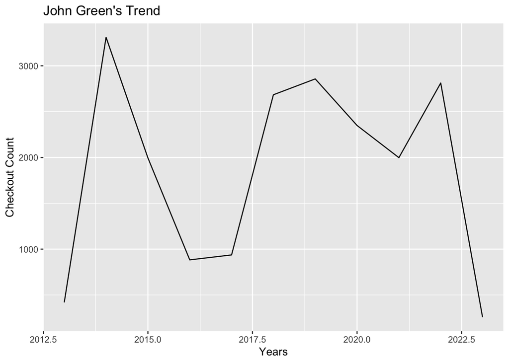

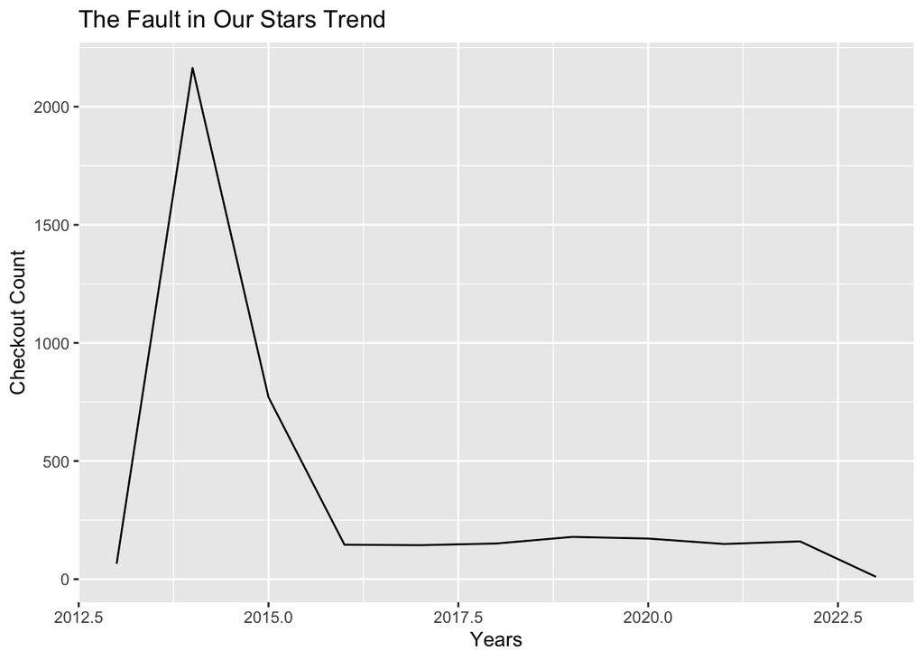

### Second Trends Over Time Chart

I included this chart because I was curious how much each book contributed to the total checkouts per year. This chart showed the trends of each book for example, the Fault in Our Stars was only most popular for 2 years, whereas Turtles All the Way Down was most popular for 7 years. The book Paper Towns was not as popular as I assumed, and only maintained popularity for one year.

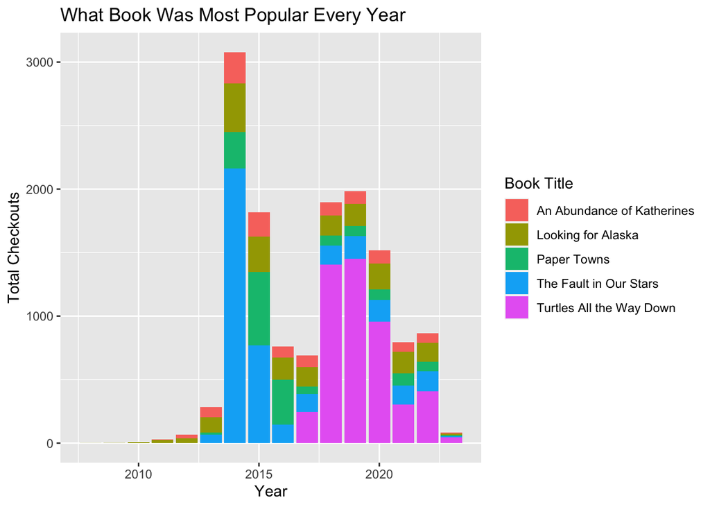

### Most Checkouts Chart

This chart shows that Turtles All the Way Down had the most checkouts, and it is important because it went against my assumption that The Fault in Our Stars was his most popular book, and Paper Towns was second most popular after The Fault in Our Stars. Instead it shows how Looking for Alaska is more popular than Paper Towns, and Turtles All the Way Down is more popular than The Fault in Our Stars.

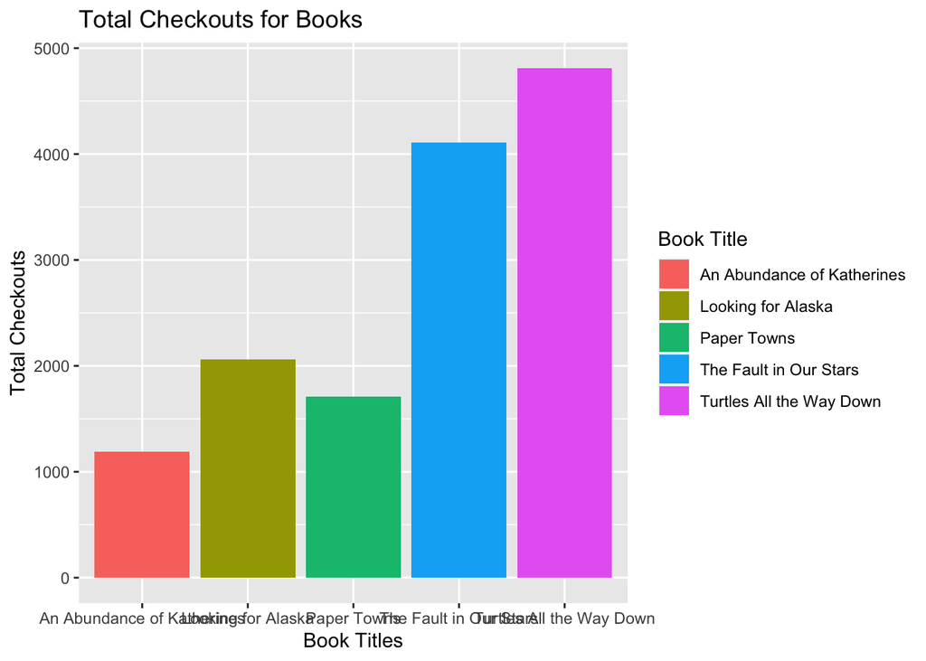